# R_Homework_4_KBush

## Toby Data

My dog (Toby) has been super annoying lately with asking to go outside way more than he has in the past. I am going to track how frequently he asks to go outside per day, how he asks to go outside (scratching at the door, growling, stomping his feet, jumping on me, etc.), how long on average he spends outside per day, and additional factors like temperature, weather, if I am already outside, etc. I am predicting his little tantrums will decrease as the temperature goes down and the weather becomes increasingly worse. I also predict he will want to go out more often when I am outside and that he will ask to go out more frequently just to get treats when he comes back in.

### Variables:

1. Date
2. Day of the week
3. Number of times asked to go outside
4. Extra measures taken to get my attention – growling, stomping, barking
5. Approximate total time spent outside – minutes
6. I am also/already outside – Y/N
7. Number of times he actually needed to go outside/use the bathroom
8. Average temperature outside – Fahrenheit
9. Rain/snow – Y/N
10. Number of treats received per day

### Google Sheets link:

https://docs.google.com/spreadsheets/d/1qCpVFeJJRBX59zaHjQlwXwpHoo9DW0Ur9LW2lo8m1UM/edit?usp=sharing

## Initial Exploratory Analysis

### Read in data and set working directory

```r
Toby <- read.csv("~/Desktop/Toby_data.csv", header=TRUE)
```

### Convert variables as needed

```r
Toby$No_times_ask <- as.numeric(Toby$No_times_ask)
Toby$Total_time <- as.numeric(Toby$Total_time)
Toby$Actual_times_used <- as.numeric(Toby$Actual_times_used)
Toby$Temp <- as.numeric(Toby$Temp)
Toby$No_treats <- as.numeric(Toby$No_treats)
Toby$Rain_snow <- as.factor(Toby$Rain_snow)
Toby$Animal <- as.factor(Toby$Animal)
```

### Summaries of continuous variables

```r
summary(Toby$Total_time)
```

```
##    Min. 1st Qu.  Median    Mean 3rd Qu.    Max.
##    4.00    8.75   10.00   12.75   15.00   45.00
```

```r
summary(Toby$Actual_times_used)
```

[output not shown]

```r
summary(Toby$No_times_ask)
```

```
##    Min. 1st Qu.  Median    Mean 3rd Qu.    Max.
##   0.000   2.000   2.000   2.188   3.000   4.000
```

```r
summary(Toby$Temp)
```

```
##    Min. 1st Qu.  Median    Mean 3rd Qu.    Max.
##   32.00   51.50   60.00   59.06   66.25   80.00
```

### Summaries of categorical variables

```r
library(Hmisc)
describe(Toby$Extra_measures)
```

```
## Toby$Extra_measures
##        n  missing distinct
##       16        0        3
##
## Foot stomping (2, 0.125), Growling (5, 0.312), None (9, 0.562)
```

```r
describe(Toby$Day_week)
```

```
## Toby$Day_week
##        n  missing distinct
##       16        0        7
##
## lowest : Friday    Monday    Saturday  Sunday    Thursday
## highest: Saturday  Sunday    Thursday  Tuesday   Wednesday
##
## Friday (2, 0.125), Monday (3, 0.188), Saturday (2, 0.125), Sunday (3,
## 0.188), Thursday (3, 0.188), Tuesday (2, 0.125), Wednesday (1, 0.062)
```

### Look at a couple of plots

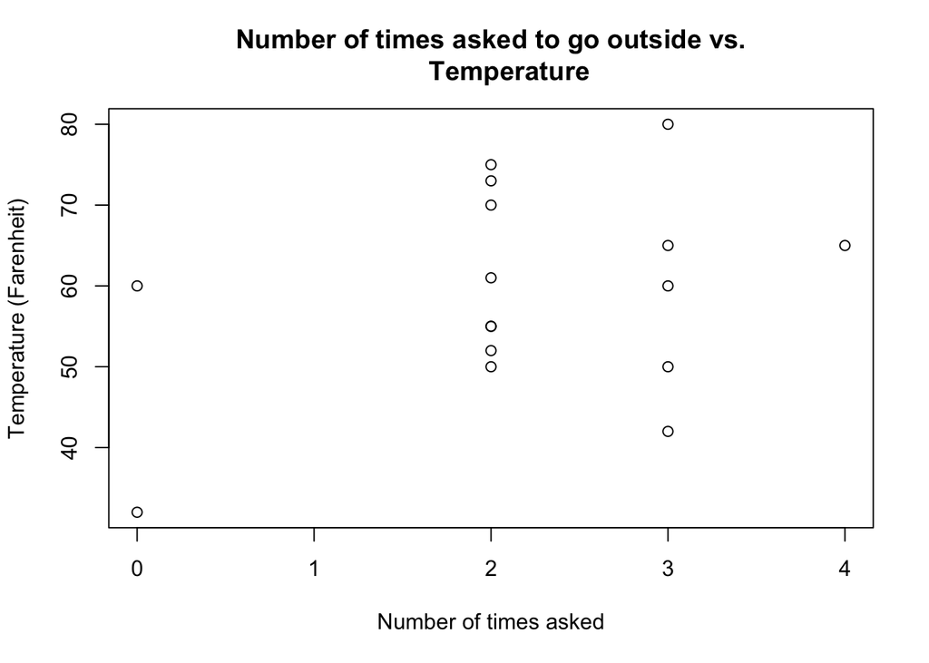

```r
plot(x=Toby$No_times_ask, y=Toby$Temp, main="Number of times asked to go outside vs.
     Temperature", xlab="Number of times asked", ylab="Temperature (Farenheit)")
```

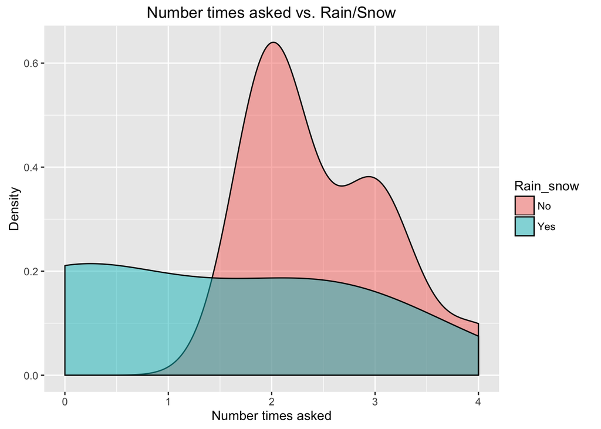

```r
library(Hmisc)
library(ggplot2)
plotA <- qplot(No_times_ask, data=Toby, geom="density",
      fill=Rain_snow, alpha=I(.5), main="Number times asked vs. Rain/Snow", xlab="Number times asked", ylab="Density")
plotA
```

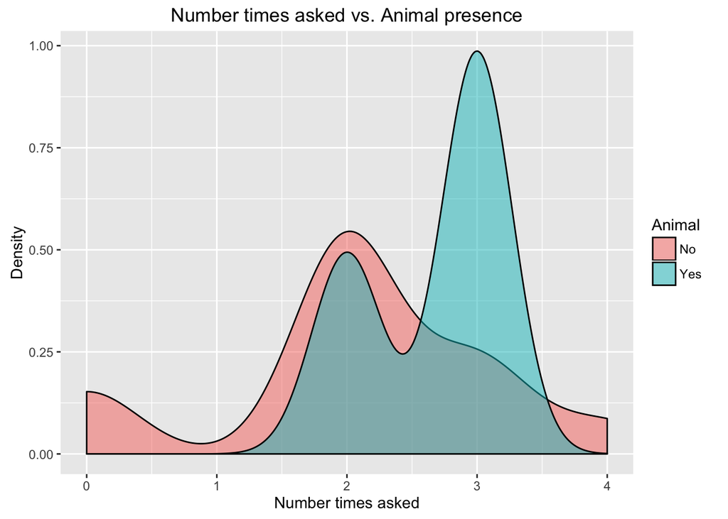

```r
plotC <- qplot(No_times_ask, data=Toby, geom="density",
      fill=Animal, alpha=I(.5), main="Number times asked vs. Animal presence", xlab="Number times asked", ylab="Density")
plotC
```

*In order for qplot ‘fill=…’ code to work, fill variable must be coded as FACTOR*

### Run some t-tests

```r
attach(Toby)
t.test(No_times_ask, Temp)
```

```
##
##  Welch Two Sample t-test
##
## data:  No_times_ask and Temp
## t = -18.101, df = 15.21, p-value = 1.055e-11
## alternative hypothesis: true difference in means is not equal to 0
## 95 percent confidence interval:
##  -63.56406 -50.18594
## sample estimates:
## mean of x mean of y
##    2.1875   59.0625
```

```r
t.test(Temp, Total_time)
```

```
##
##  Welch Two Sample t-test
##
## data:  Temp and Total_time
## t = 11.879, df = 27.673, p-value = 2.227e-12
## alternative hypothesis: true difference in means is not equal to 0
## 95 percent confidence interval:
##  38.32215 54.30285
## sample estimates:
## mean of x mean of y
##   59.0625   12.7500
```